# Assignment 3: Model comparison

Marton Kovacs

In this lab assignment you are going to work with (simulated) data related to perioperative pain and its psychological and hormonal predictors. In the assignment you will assess the added benefit of including some psychological and hormonal predictors to the already established demographic predictors of pain.

In this assignment you will set up a hierarchical regression model to predict postoperative pain after wisdom tooth surgery.

# Research problem

The amount of pain experienced around and after surgeries are highly variable between and within individuals. In order to improve surgical pain management regimens we need to understand what influences pain around surgical procedures and predict the amount of pain an individual will experience.

Your first study in this area is related to assessing the influence of trait and state psychological measures on pain, and to see whether taking into account these variables can improve our understanding of postoperative pain.

# Procedures and measures

Use the data file called ‘assignment_3_dataset’, from the ‘data/’ folder.

You have collected data from 160 adults who were scheduled to undergo surgical extraction of the third mandibular molar (wisdom tooth surgery). Patients filled out a form in the waiting room before their surgery. The form contained questions about their sex, age, and weight, and psychological questionnaires assessing anxiety, pain catastrophizing, and mindfulness (see descriptions below). You also got blood samples and saliva samples from participants in the waiting room 5 minutes before their operations to determine the serum (a component of the blood) and salivary cortisol levels of participants. Participants were contacted 5 hours after the surgery to see how much pain they were experiencing. The **level of pain** at that moment was recorded using a numerical rating scale using a **scale of 0 to 10**, where 0 means “no pain” and 10 means “worst pain I can imagine”.

**The State Trait Anxiety Inventory:** T measures trait anxiety on a scale of 20 to 80, higher scores mean higher anxiety. Anxiety has been found in many studies to positively correlate with the level of pain experienced. This is **variable STAI_trait** in the dataset.

**The Pain Catastrophizing Scale** measures the extent of pain catastrophizing, which is characterized by a tendency to magnify the threat value of a pain stimulus and to feel helpless in the presence of pain, as well as by a relative inability to prevent or inhibit pain-related thoughts in anticipation of, during, or following a painful event. The total score on this scale ranges from 0 to 52, higher scores mean higher catastrophizing. Pain catastrophizing is one of the well-established predictors of clinical pain. This is **variable pain_cat** in the dataset.

**The Mindful Attention Awareness Scale (MAAS)** measures dispositional mindfulness, which may be described as a tendency to turn attention to present-moment experiences in an open, non-judgmental way. The MAAS total score ranges from 1 to 6 (an average of the item scores), with higher scores representing higher dispositional mindfulness. Trait mindfulness has been theorized to serve as a protective factor against pain, as the individual would be more objective about their pain experience and tend to associate less discomfort, despair, and hopelessness to the pain-related sensations. This is **variable mindfulness** in the dataset.

**Cortisol** is a stress hormone associated with acute and chronic stress. Cortisol levels are thought to be positively associated with pain experience. Cortisol can be **measured from both blood and the saliva**, although, serum cortisol is often regarded in medical research as more reliably related to stress (serum is a component of the blood plasma). These are **variables cortisol_serum**, and **cortisol_saliva** in the dataset.

# Research question

Previous studies and meta-analyses showed that age and sex are often predictors of pain (age is negatively associated with pain, while sex is a predictor more dependent on the type of the procedure). You would like to determine the extent to which taking into account psychological and hormonal variables aside from the already used demographic variables would improve our understanding of postoperative pain.

To answer this research question you will **need to compare two models** (with a hierarchical regression). The **simpler model** should contain **age and sex as predictors of pain**, while the **more complex model** should contain the **predictors: age, sex, STAI, pain catastrophizing, mindfulness, and cortisol measures**. Notice that the predictors used in the simpler model are a subset of the predictors used in more complex model. **You will have to do model comparison to assess whether substantial new information was gained about pain in the more complex model compared to the simpler model.**

# What to report

As usual, before you can interpret your model, you will need to run data and model diagnostics. First, check the variables included in the more complex model (age, sex, STAI, pain catastrophizing, mindfulness, and cortisol measures as predictors, and pain as an outcome) for **coding errors**, and the model itself for **influential outliers** (for example using Cook’s distance). Furthermore, check the final model to see if the **assumptions of linear regression hold true**, that is, **normality** (of the residuals), **linearity** (of the relationship), **homogeneity of variance** (also called homoscedasticity) and that there is no excess **multicollinearity** (“uncorrelated predictors” in Navarro’s words). If you find anything amiss during these checks, make the appropriate decision or correction and report your findings and actions in your report.

**Note:** If you do any changes, such as exclude cases, or exclude predictors from the model, you will have to re-run the above checks for your final data and model.

Report the results of the simpler model and the more complex model. For both models you should report the model test statistics (adj.R2, F, df, and p value). Also, report the statistics describing the coefficients of the predictors in a table format (unstandardized regression coefficients and 95% confidence intervals, standardized regression coefficients (B and Beta values), and p values).

Write up the regression equation of the more complex model in the form of 𝑌 = 𝑏0 + 𝑏1 ∗ X1 + 𝑏2 ∗ X2 +…+ bn * Xn, in which you use the actual regression coefficients of your models. (b0 stands for the intercept and b1, b2 … bn stand for the model coefficients for each of the predictors, and X1, X2, … Xn denote the predictors).

Compare the two models in terms of how much variance they explain of pain’s variability in the sample. Report Akaike information criterion (AIC) for both models and the F test statistic and p value of the likelihood ratio test comparing the two models.

# What to discuss

In your discussion of the findings, briefly interpret the results of the above analyses, and indicate whether you think that anything was gained by including the psychological and hormone measures in the model.

# Solution

## Read the data

Read the dataset used in this assignment. Pay attention to the extension of the datafile.

```r
library(readxl)

data <- read_excel("../data/assignment_3_dataset.xlsx")
```

## Data and model diagnostics

### Data diagnostics

#### Descriptives of the variables

Run an exploratory data analysis (EDA) to investigate the dataset.

```r
library(dplyr)
```

```r
library(ggplot2)
library(skimr)
library(corrplot)
library(tidyr)

# Preview the data
head(data)
```

```
## # A tibble: 6 × 12
##   ID     pain sex      age STAI_t…¹ pain_…² corti…³ corti…⁴ mindf…⁵ weight    IQ
##   <chr> <dbl> <chr>  <dbl>    <dbl>   <dbl>   <dbl>   <dbl>   <dbl>  <dbl> <dbl>
## 1 ID_1      5 female    38       39      25    4.67    4.78    3.83   62.1    99
## 2 ID_2      4 female    36       46      31    6.01    6.71    2.82   97.1    71
## 3 ID_3      5 female    51       49      32    5.18    4.75    3.93   79.0    97
## 4 ID_4      7 female    39       48      41    6.65    6.68    1.9    78.5    97
## 5 ID_5      4 male      48       36      26    2.95    3.2     4.39   76.9   129
## 6 ID_6      6 female    45       37      28    4.32    4.36    3.01   47.2   115
## # … with 1 more variable: household_income <dbl>, and abbreviated variable
## #   names ¹STAI_trait, ²pain_cat, ³cortisol_serum, ⁴cortisol_saliva,
## #   ⁵mindfulness
```

```r
# Check the structure of the data
str(data)
```

```
## tibble [160 × 12] (S3: tbl_df/tbl/data.frame)
##  $ ID              : chr [1:160] "ID_1" "ID_2" "ID_3" "ID_4" ...
##  $ pain            : num [1:160] 5 4 5 7 4 6 4 5 4 5 ...
##  $ sex             : chr [1:160] "female" "female" "female" "female" ...
##  $ age             : num [1:160] 38 36 51 39 48 45 45 35 39 33 ...
##  $ STAI_trait      : num [1:160] 39 46 49 48 36 37 34 39 31 38 ...
##  $ pain_cat        : num [1:160] 25 31 32 41 26 28 22 32 27 36 ...
##  $ cortisol_serum  : num [1:160] 4.67 6.01 5.18 6.65 2.95 4.32 5.32 5.26 3.36 5.96 ...
##  $ cortisol_saliva : num [1:160] 4.78 6.71 4.75 6.68 3.2 4.36 5.19 5.53 3.3 5.78 ...
##  $ mindfulness     : num [1:160] 3.83 2.82 3.93 1.9 4.39 3.01 4.97 2.95 3.43 1.85 ...
##  $ weight          : num [1:160] 62.1 97.1 79 78.5 76.9 ...
##  $ IQ              : num [1:160] 99 71 97 97 129 115 74 98 93 76 ...
##  $ household_income: num [1:160] 52505 64993 68598 47822 100580 ...
```

```r
# Summary statistics
summary(data)
```

```
##       ID                 pain            sex                 age
##  Length:160         Min.   : 1.000   Length:160         Min.   :24.00
##  Class :character   1st Qu.: 4.000   Class :character   1st Qu.:38.00
##  Mode  :character   Median : 5.000   Mode  :character   Median :41.00
##                     Mean   : 5.194                      Mean   :40.74
##                     3rd Qu.: 6.000                      3rd Qu.:44.00
##                     Max.   :50.000                      Max.   :53.00
##    STAI_trait       pain_cat     cortisol_serum  cortisol_saliva
##  Min.   :26.00   Min.   :14.00   Min.   :2.700   Min.   :2.530
##  1st Qu.:37.00   1st Qu.:27.00   1st Qu.:4.268   1st Qu.:4.120
##  Median :40.00   Median :30.00   Median :4.995   Median :5.035
##  Mean   :40.09   Mean   :29.88   Mean   :4.941   Mean   :4.952
##  3rd Qu.:43.00   3rd Qu.:32.25   3rd Qu.:5.633   3rd Qu.:5.753
##  Max.   :52.00   Max.   :42.00   Max.   :7.110   Max.   :7.190
##   mindfulness        weight            IQ         household_income
##  Min.   :1.000   Min.   :33.80   Min.   : 52.00   Min.   :  5548
##  1st Qu.:2.595   1st Qu.:62.15   1st Qu.: 91.75   1st Qu.: 53489
##  Median :3.115   Median :68.77   Median :101.00   Median : 72149
##  Mean   :3.204   Mean   :68.57   Mean   :100.74   Mean   : 70426
##  3rd Qu.:3.830   3rd Qu.:74.65   3rd Qu.:109.00   3rd Qu.: 87734
##  Max.   :6.220   Max.   :97.13   Max.   :144.00   Max.   :139268
```

```r
# Check for missing data
colSums(is.na(data))
```

```
##               ID             pain              sex              age
##                0                0                0                0
##       STAI_trait         pain_cat   cortisol_serum  cortisol_saliva
##                0                0                0                0
##      mindfulness           weight               IQ household_income
##                0                0                0                0
```

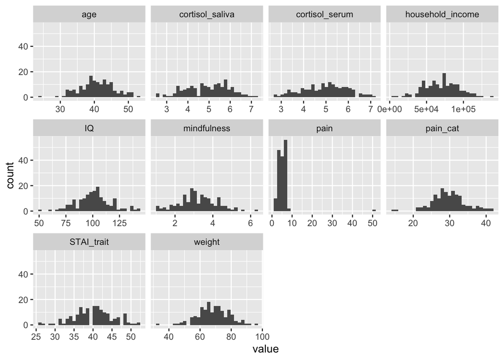

```r
# Conclusion: no missing data

# Plot histograms for all numeric variables
data %>%
  select(where(is.numeric)) %>%
  gather() %>%
  ggplot(aes(x = value)) +
  geom_histogram(bins = 30) +
  facet_wrap(~ key, scales = 'free_x')
```

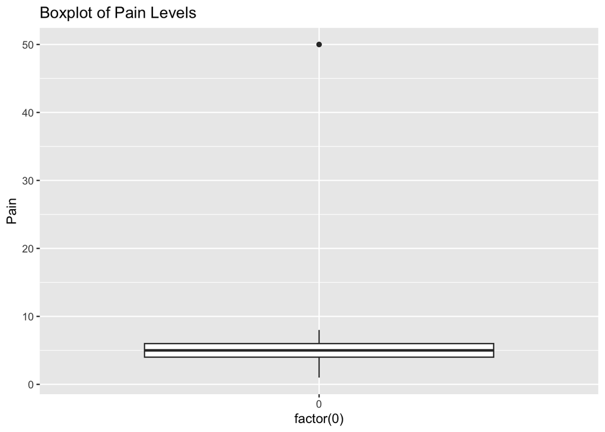

```r
# Conclusion: In the case of pain, there is an outlier, the others appear to be normally distributed

# Boxplot for numerical variables to check for outliers
ggplot(data, aes(x = factor(0), y = pain)) +
  geom_boxplot() +
  ylab("Pain") +
  ggtitle("Boxplot of Pain Levels")
```

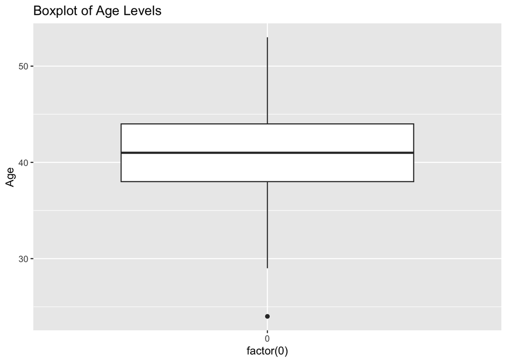

```r
# Conclusion: There is an outlier that needs to be removed because its value is very high.

ggplot(data, aes(x = factor(0), y = age)) +
  geom_boxplot() +
  ylab("Age") +
  ggtitle("Boxplot of Age Levels")
```

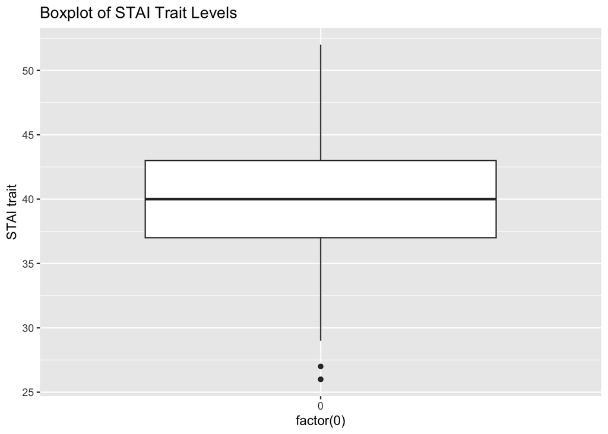

```r
# Conclusion: There is an outlier that I decided not to remove because it has no effect on the normal distribution.

ggplot(data, aes(x = factor(0), y = STAI_trait)) +
  geom_boxplot() +
  ylab("STAI trait") +
  ggtitle("Boxplot of STAI Trait Levels")
```

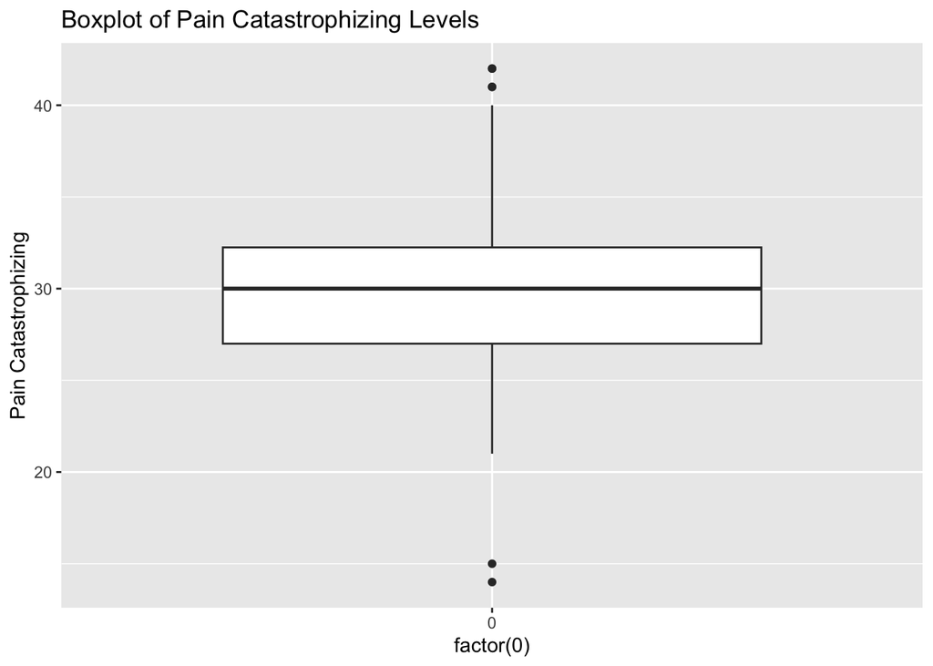

```r
# Conclusion: There are outliers that I decided not to remove because it has no effect on the normal distribution.

ggplot(data, aes(x = factor(0), y = pain_cat)) +
  geom_boxplot() +
  ylab("Pain Catastrophizing") +
  ggtitle("Boxplot of Pain Catastrophizing Levels")
```

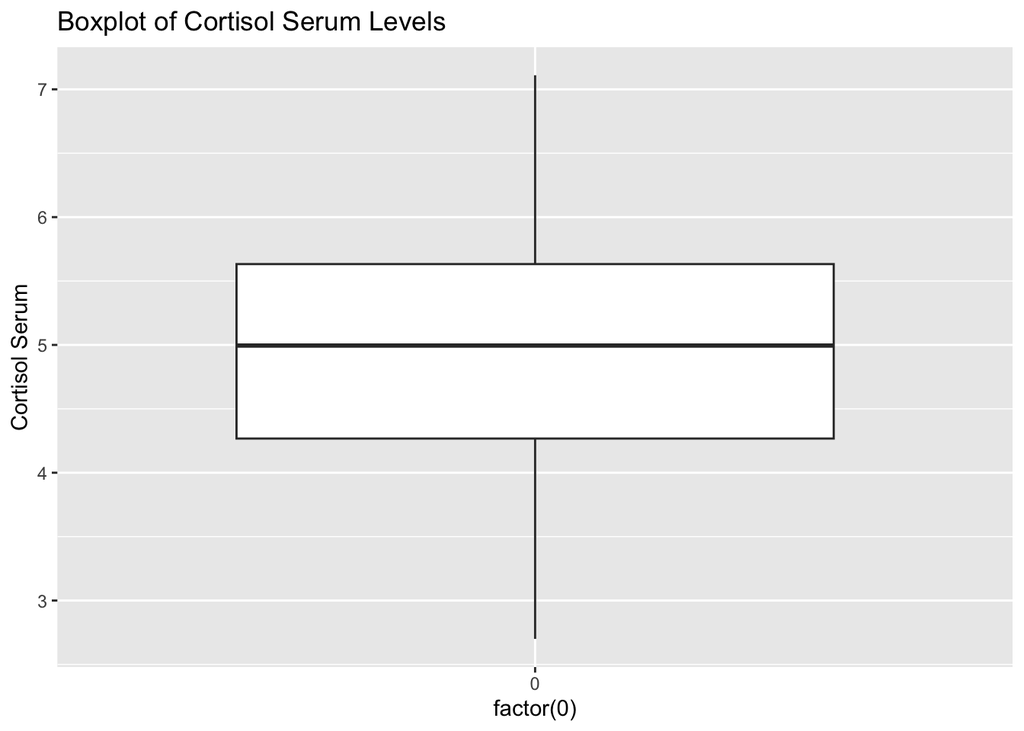

```r
# Conclusion: There are outliers that I decided not to remove because it has no effect on the normal distribution.

ggplot(data, aes(x = factor(0), y = cortisol_serum)) +
  geom_boxplot() +
  ylab("Cortisol Serum") +
  ggtitle("Boxplot of Cortisol Serum Levels")
```

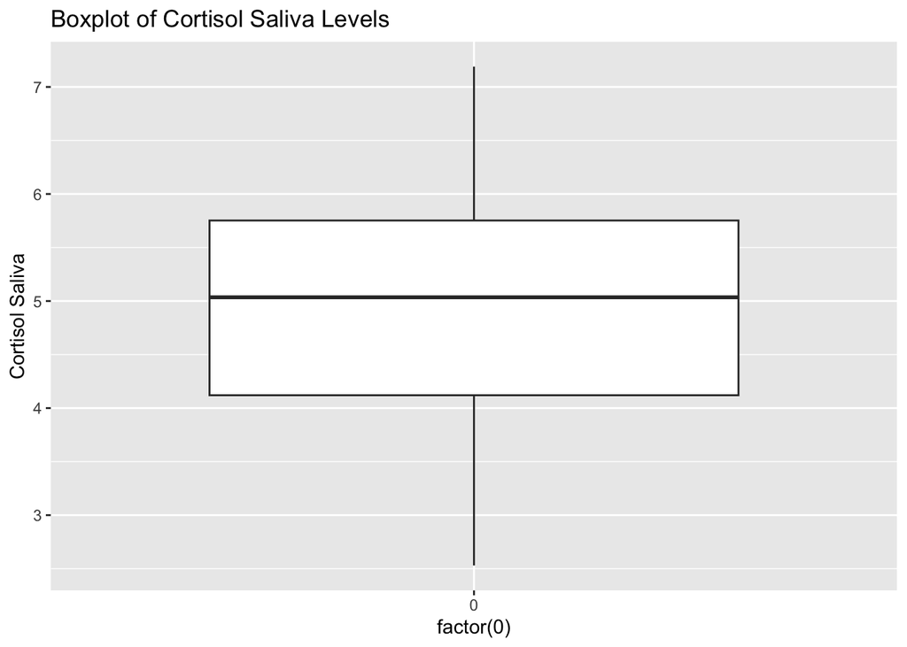

```r
# Conclusion: No outliers.

ggplot(data, aes(x = factor(0), y = cortisol_saliva)) +
  geom_boxplot() +
  ylab("Cortisol Saliva") +
  ggtitle("Boxplot of Cortisol Saliva Levels")
```

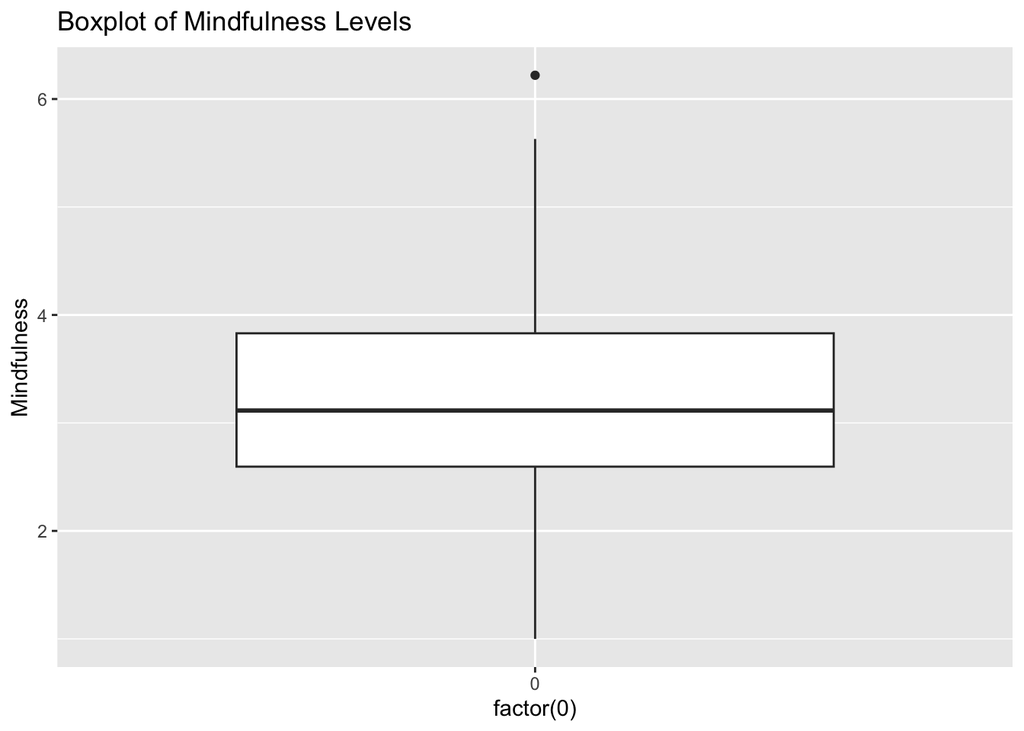

```r
# Conclusion: No outliers.

ggplot(data, aes(x = factor(0), y = mindfulness)) +
  geom_boxplot() +
  ylab("Mindfulness") +
  ggtitle("Boxplot of Mindfulness Levels")
```

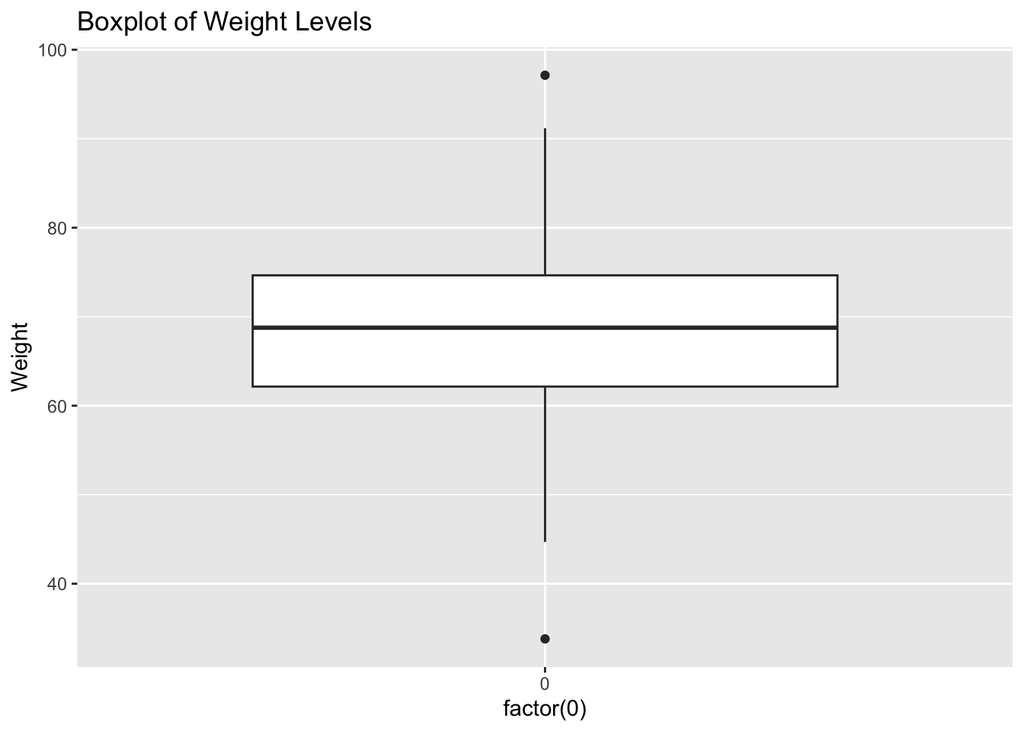

```r
# Conclusion: There is an outlier that I decided not to remove because it has no effect on the normal distribution.

ggplot(data, aes(x = factor(0), y = weight)) +
  geom_boxplot() +
  ylab("Weight") +
  ggtitle("Boxplot of Weight Levels")
```

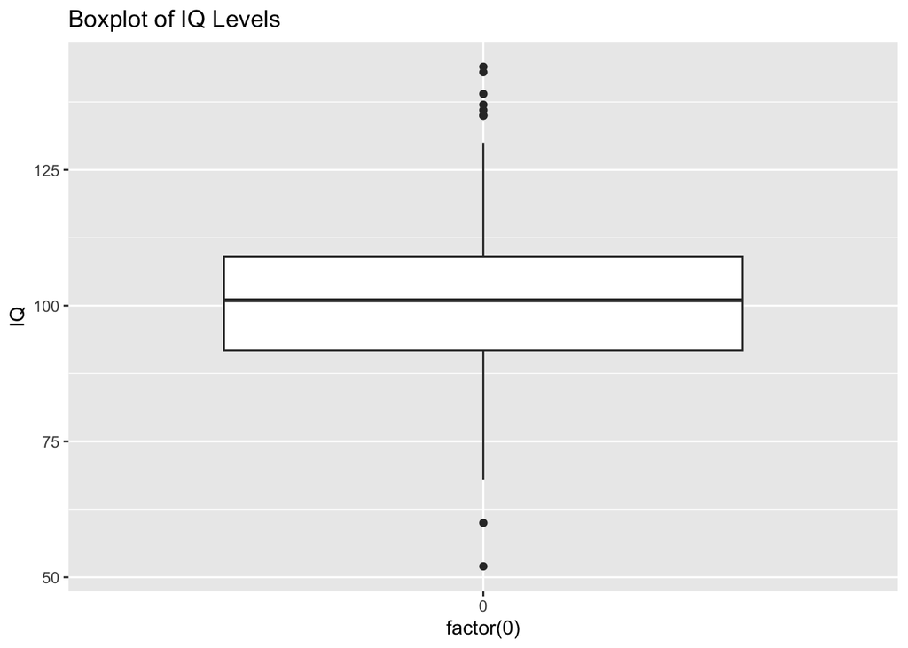

```r
# Conclusion: I decided to remove the oulier under 40 kg because it is a very low body weight, I assume it is a typo

ggplot(data, aes(x = factor(0), y = IQ)) +
  geom_boxplot() +
  ylab("IQ") +
  ggtitle("Boxplot of IQ Levels")
```

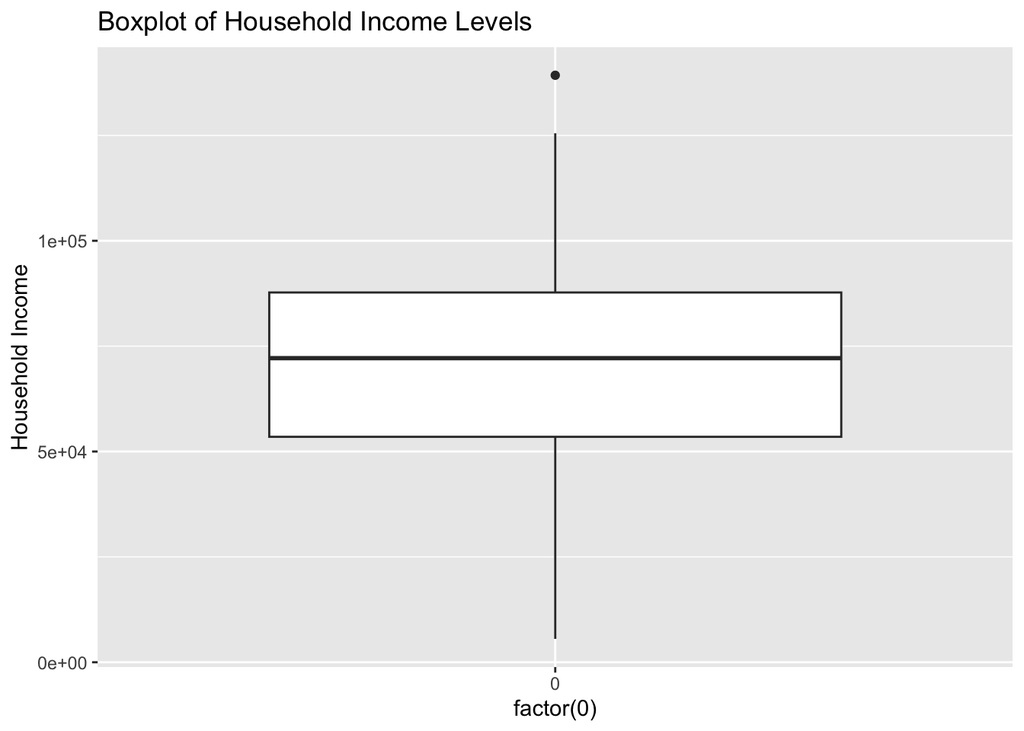

```r
# Conclusion: I decided to remove the ouliers under IQ 70 because they are very low

ggplot(data, aes(x = factor(0), y = household_income)) +
  geom_boxplot() +
  ylab("Household Income") +
  ggtitle("Boxplot of Household Income Levels")
```

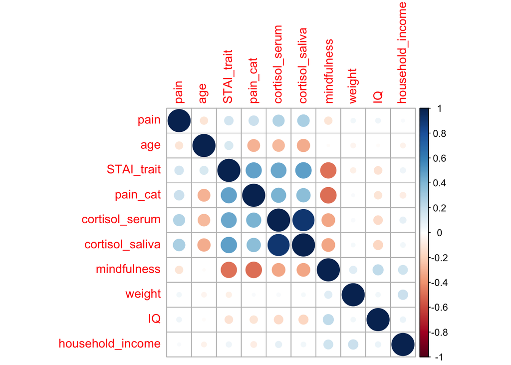

```r
# Conclusion: There is an outlier that I decided not to remove because it has no effect on the normal distribution.

# Calculate correlation matrix for numerical variables
cor_matrix <- cor(data %>% select(where(is.numeric)), use = "complete.obs")
# Plot correlation matrix
corrplot(cor_matrix, method = "circle")
```

```r
# Conclusion: The strong correlation between Cortisol Serum and Cortisol Saliva should be taken into account in further statistical analyses

# Check distribution of categorical variables
table(data$sex)
```

```
##
## female   male  woman
##     83     76      1
```

```r
# Conclusion: One of the category variables is written out, woman should be changed to female.
```

#### Correct coding errors

If you find values in the dataset during the EDA, that are not correct based on the provided descriptions of the variables of the dataset please correct them here.

```r
library(car)
# Adjust according to the correct pain range
data <- data %>% filter(pain <= 10)

# Recode the gender variable
data$sex <- recode(data$sex, "'woman' = 'female'")


# Not relevant for the modell but I removed the following outliers:

# Remove body weight entries that are below 40 kg
data <- data %>% filter(weight >= 40)

# Remove outliers of very low IQ
data <- data %>% filter(IQ >= 70)
```

### Model diagnostics

#### Build the more complex model

In order to test the more complex model for outliers and to test the assumptions first build the model.

```r
model_complex <- lm(pain ~ age + sex + STAI_trait + pain_cat + mindfulness + cortisol_serum + cortisol_saliva, data = data)
```

#### Checking for influential outliers

Check for outlier values in the model.

```r
# Calculate Cook's distance
cooks_dist <- cooks.distance(model_complex)

# Print the observations with Cook's distance > 1
influential <- which(cooks_dist > 1)
print(influential)
```

```
## named integer(0)
```

```r
# There are no observations with a Cook's distance above 1, suggesting that no individual data point has a disproportionately large influence on the regression model.
```

#### Checking assumptions

Check the normality assumption.

```r
# Shapiro-Wilk test for normality
shapiro.test(residuals(model_complex))
```

```
##
##  Shapiro-Wilk normality test
##
## data:  residuals(model_complex)
## W = 0.9936, p-value = 0.7278
```

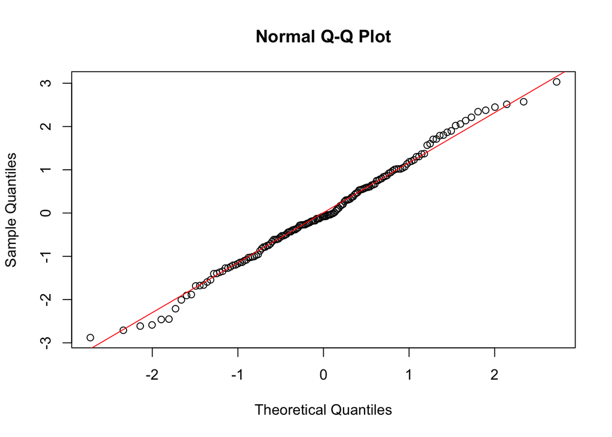

```r
# Q-Q plot of residuals
qqnorm(residuals(model_complex))
qqline(residuals(model_complex), col = "red")
```

```r
# Conclusion: The Shapiro-Wilk normality test indicates that the residuals follow a normal distribution (W = 0.9936, p-value = 0.7278), as the p-value is greater than the commonly used significance level of 0.05.
```

Check the linearity assumption.

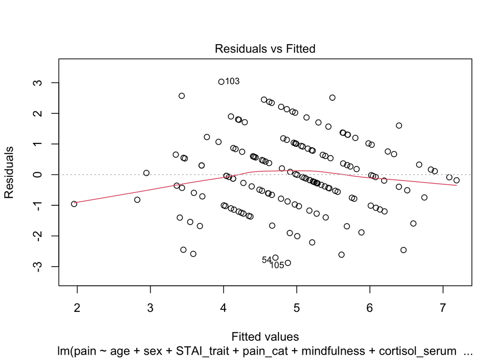

```r
# Residuals vs Fitted plot
plot(model_complex,1)
```

```r
# Based on the scatter plot of the given residuals vs. fitted values, the linearity condition is not perfectly met.
```

Check the homoscedasticty assumption (homogeneity of variance).

```r
library(lmtest)
bptest(model_complex)
```

```
##
##  studentized Breusch-Pagan test
##
## data:  model_complex
## BP = 11.077, df = 7, p-value = 0.1353
```

```r
# Conclusion: The results of the Breusch-Pagan test (BP = 11.077, p-value = 0.1353) suggest that there is no significant evidence of heteroscedasticity in the model, indicating that the assumption of homoscedasticity holds.
```

Check the multicollinearity assumption.

Some info about VIF: https://statisticalhorizons.com/multicollinearity http://blog.minitab.com/blog/understanding-statistics/handling-multicollinearity-in-regression-analysis

```r
library(car)

vif(model_complex)
```

```
##             age             sex      STAI_trait        pain_cat     mindfulness
##        1.504797        1.156356        2.092752        1.943899        1.526466
##  cortisol_serum cortisol_saliva
##        6.086623        6.633804
```

```r
# The VIF values indicate that while most predictors have no significant multicollinearity, the cortisol_serum and cortisol_saliva variables show higher VIF values, suggesting potential multicollinearity between them, which may require further investigation or adjustment.
```

### Making decision based on model diagnostics

If based on the assumption tests you decide to drop a predictor variable you should do that here. Create your updated model.

```r
# I will keep cortisol_serum because, as I know, it is generally considered a more reliable and commonly used measure in medical research for assessing stress and its relation to pain

updated_model_complex <- lm(pain ~ age + sex + STAI_trait + pain_cat + mindfulness + cortisol_serum, data = data)
```

#### Checking outliers of the updated model

```r
# Calculate Cook's distance
cooks_dist <- cooks.distance(updated_model_complex)

# Print the observations with Cook's distance > 1
influential <- which(cooks_dist > 1)
print(influential)
```

```
## named integer(0)
```

```r
# There are no observations with a Cook's distance above 1, suggesting that no individual data point has a disproportionately large influence on the regression model.
```

#### Checking assumptions of the updated model

Normality assumption

```r
# Shapiro-Wilk test for normality
shapiro.test(residuals(updated_model_complex))
```

```
##
##  Shapiro-Wilk normality test
##
## data:  residuals(updated_model_complex)
## W = 0.99172, p-value = 0.5086
```

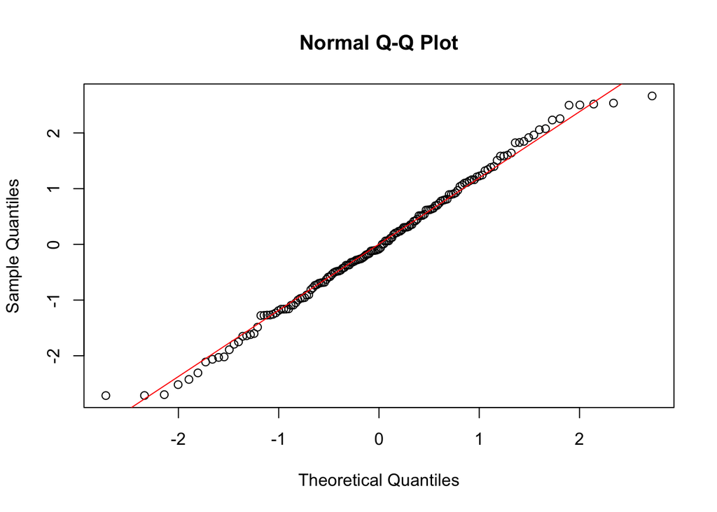

```r
# Q-Q plot of residuals
qqnorm(residuals(updated_model_complex))
qqline(residuals(updated_model_complex), col = "red")
```

```r
# Conclusion: The Shapiro-Wilk normality test indicates that the residuals follow a normal distribution (W = 0.99172, p-value = 0.5086), as the p-value is greater than the commonly used significance level of 0.05.
```

Linearity assumption

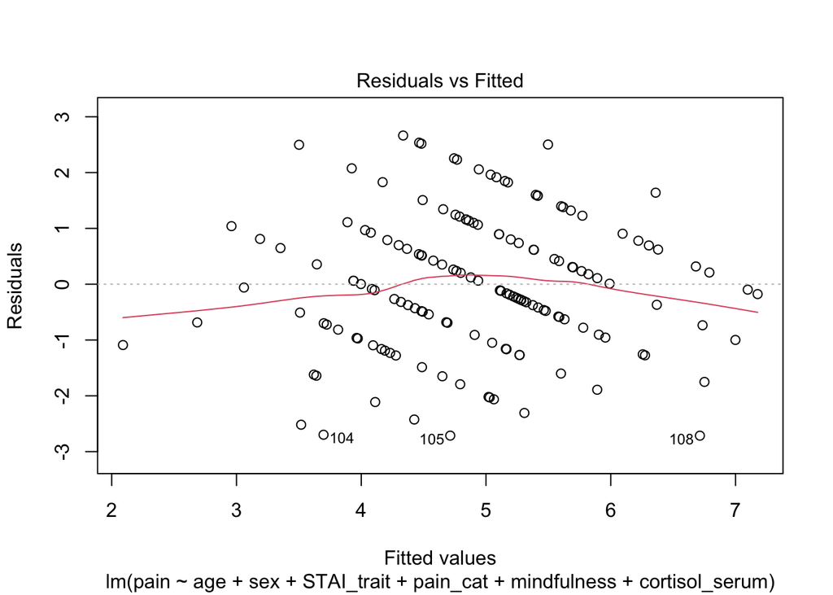

```r
# Residuals vs Fitted plot
plot(updated_model_complex,1)
```

```r
# Based on the scatter plot of the given residuals vs. fitted values, the linearity condition is not perfectly met.
```

Homoscedasticty assumption (homogeneity of variance)

```r
library(lmtest)

bptest(updated_model_complex)
```

```
##
##  studentized Breusch-Pagan test
##
## data:  updated_model_complex
## BP = 9.882, df = 6, p-value = 0.1297
```

```r
# Conclusion: The results of the Breusch-Pagan test (BP = 9.882, p-value = 0.1297) suggest that there is no significant evidence of heteroscedasticity in the model, indicating that the assumption of homoscedasticity holds.
```

Multicollinearity assumption

```r
library(car)

vif(updated_model_complex)
```

```
##            age            sex     STAI_trait       pain_cat    mindfulness
##       1.383881       1.154361       1.933766       1.864050       1.516543
## cortisol_serum
##       1.511927
```

```r
# The VIF values indicate that predictors have no significant multicollinearity.
```